# Assessing the Difference in Preterm Birth Mortality by Region in Ethiopia

Data Science for Biomedical Informatics (BMIN503/EPID600)

Author

Derartu Ahmed

# Overview

Southern Asia and sub-Saharan Africa have the highest rates of preterm birth. Furthermore, babies in this regions face the hugest mortality risk. Ethiopia is among the top 15 countries that contribute to two-thirds of the world’s preterm babies. The goal of this project is to perform statistical analyses to assess the relationships between preterm mortality and regions in Ethiopia.

## Introduction

Despite the many efforts over the last decades, there has been no measurable change in preterm birth rates at a global level. In 2020, the estimated number of preterm births was 13.4 million, compared to 13.8 million preterm in 2010 globally. Of this, 65% of them are in sub-Saharan Africa and South Asia.

Notably, gaps in national routine data for preterm birth in the most affected regions have made it harder to address the gap in knowledge of mortality and the morbidity associated with preterm birth. Preterm babies are at a higher risk of disability and developmental delays, potentially leading to lifelong health consequence. Therefore, understanding the key population impacted by preterm mortality is important to decreasing preterm births and improving outcomes.

Ethiopia, a country in sub-Saharan Africa, contributes to two-thirds of the world’s preterm babies, with an estimated preterm birth rate of 14.1%. While it is common to have disparities in health service utilization within and between regional states of countries with diverse sociocultural and economic conditions such as Ethiopia, it is important to address avoidable differences within regions. Therefore, this analysis aims to assess if there is a difference in preterm mortality by region in Ethiopia.

### Dataset description

This data was imported from ClinEpiDB, a clinical epidemiology database. The data is from a longitudinal cohort study of preterm birth outcomes conducted in three different regions in Ethiopia: Oromia region, the Amhara region, and the capital, Addis Ababa. Preterm infants <7 days old were enrolled and followed over the first 28 days of life or until death. The dataset includes information on birth place, birth location, and many other clinical characteristics outcome for all preterm birth including causes of death. For maternal characteristics, socio-demographic, obstetric, and maternal factors were collected.

I primarily discussed my data with Dr. Elizabeth Lowenthal. Our focus centered on identifying key factors for assessing preterm mortality and regional variations. Variables we deemed crucial for consideration included maternal age, martial status, occupation, and parity. For infants, factors such as birth location, gestational age at birth, birth weight, and mortality were considered.

# Methods

## R Libraries

First, all necessary packages are loaded first to keep the code organized.

```r
#load necessary Packages
library(tidyverse)
library(ggplot2)
library(knitr)
library(grid)
library(gridExtra)
library(dplyr)
library(pwr)
library(tidyr)
library(tibble)
library(leaflet)
library(sf)
library (epitools)
library(epiR)
library(gtsummary)
library(cowplot)
library (patchwork)
```

## Pre-processing/Merging data

This block of code imports the raw data extracted from ClinEpiDB which is a clinical epidemiology data base. The data is from a longitudinal cohort study of preterm birth conducted in three different regions in Ethiopia: Oromia region, the Amhara region, and the capital, Addis Ababa (Map of Ethiopia with the different regions is provided below). Data set titled “household” and “participant” were merged on the variable “household ID”.

```r
# looking for working directory
current_directory <- getwd()
#loading in data from folder
#household data = 4,919 ( data of hospital and region of participant)
house_data <- read.delim("/Users/ahmedd/Desktop/SIP Data/Household_subsettedData.txt")
head(house_data,5)

#  participant data = 4,919 ( background of mother and infant)
parti_data <- read.delim("/Users/ahmedd/Desktop/SIP Data/Participant_subsettedData.txt")
head(parti_data,5)


# data repeated measure= 36779
repeatedm_data <- read.delim("/Users/ahmedd/Desktop/SIP Data/repeated measure_subsettedData.txt")
head(repeatedm_data,5)

# merging household and participant demographic data on the Household_ID column
merged_data <- merge(house_data, parti_data, by = "Household_ID", all = TRUE)
head(merged_data,5)
```

## Data cleaning

The data cleaning steps involved several actions: renaming certain variables for easier access, adding new columns named “region” based on the hospital collection site(e.g Gondar University Hospital corresponds to the Amhara Region), and “mortality” based on those with information on cause of death.

```r
# Rename specific columns in the original data frame
colnames(merged_data)[colnames(merged_data) == "Sex..PATO_0000047."] <- "sex"
colnames(merged_data)[colnames(merged_data) == "Birth.weight..g...EFO_0004344."] <- "birthweight"
colnames(merged_data)[colnames(merged_data) == "Gestational.age.at.delivery..weeks...NCIT_C124435."] <- "gestageweeksatdelivery"
colnames(merged_data)[colnames(merged_data) == "Birth.place..EUPATH_0012417."] <- "birthlocation"
colnames(merged_data)[colnames(merged_data) == "Birth.location..EUPATH_0038716."] <- "birthplace"
colnames(merged_data)[colnames(merged_data) == "Hospital..EUPATH_0038001."] <- "hospitalname"
colnames(merged_data)[colnames(merged_data) =="Mother.s.1st.pregnancy..EUPATH_0038014."] <- "firstpreg"
colnames(merged_data)[colnames(merged_data) =="Mother.s.age..years...EUPATH_0035109."] <- "maternalage"
colnames(merged_data)[colnames(merged_data) =="Mother.s.occupation..EUPATH_0036221."] <- "occupation"
colnames(merged_data)[colnames(merged_data) =="Mother.s.marital.status..EUPATH_0048083."] <- "maritalstatus"
colnames(merged_data)[colnames(merged_data) =="Mother.s.education.level..EUPATH_0036220."] <- "educationlevel"

# Create a new column region based on hospital name
merged_data <- merged_data %>%
  mutate(region = case_when(
   hospitalname == "Gondar University Hospital" ~ "Amhara region",
   hospitalname == "Jimma University Hospital" ~ "Oromia region",
    hospitalname %in% c("Ghandi Memorial Hospital", "St. Paul's Hospital", "Tikur Anbessa Hospital") ~ "Addis Ababa",
    TRUE ~ "Other"
  ))
table(merged_data$region)

# Filter the data to select rows where "Sex" is neither "Male" nor "Female"
filtered_data <- merged_data %>%
  filter(sex != "Male" & sex != "Female")

# Create a new column mortality based on those with cause of death record cause.
merged_data$mortality <- ifelse(merged_data$Cause.of.death..by.clinician..EUPATH_0038269. == "", 0, 1)
#convert mortality from characteric to numeric
merged_data$mortality <- as.numeric(merged_data$mortality)
#checking  mortality data output for possible error (comparing #'s to original dataset)
table (merged_data$mortality)

#changing frist pregnancy from yes/no to 0/1
merged_data$firstpreg <- ifelse(merged_data$firstpreg =="No", 0, 1)
#convert mortality from characteric to numeric
merged_data$firstpregnum <- as.numeric(merged_data$firstpreg)
```

# Results

## Map of Location of study

All the samples were included in the analysis. The study participants were preterm infants born at or referred within 7 days to northwestern Ethiopia (Gondar University Hospital), in southwestern Ethiopia (Jimma University Hospital), and three hospitals in Addis Ababa (Ghandi Memorial Hospital, St Paul’s Hospital Millennium Medical College, and Tikur Anbessa Hospital). A map of Ethiopia showing the study regions is included below.

```r
#creating a map for of Ethiopia with region labeled
# Download and unzip the GeoJSON file
url <- "https://geodata.ucdavis.edu/gadm/gadm4.1/json/gadm41_ETH_1.json.zip"
download.file(url, destfile = "gadm41_ETH_1.json.zip")
unzip("gadm41_ETH_1.json.zip", exdir = "ethiopian_data")

# Read the GeoJSON file using sf
ethiopian_data <- st_read("ethiopian_data/gadm41_ETH_1.json")
# Check the structure
str(ethiopian_data)
# Create color palette
unique_names <- unique(ethiopian_data$NAME_1)
pal <- colorFactor(palette = "Blues", domain = unique_names)
```

```r
# Plot the map
leaflet(ethiopian_data) %>%
  addTiles() %>%
  addPolygons(
    fillColor = ~pal(NAME_1),
    weight = 2,
    opacity = 1,
    color = "white",
    dashArray = "3",
    fillOpacity = 0.7,
    highlight = highlightOptions(
      weight = 5,
      color = "#666",
      dashArray = "",
      fillOpacity = 0.7,
      bringToFront = TRUE
    ),
    label = ~as.character(NAME_1)
  ) %>%
  addLegend(pal = pal, values = unique_names, title = "Regions")
```

[interactive chart not shown]

## Infant Baseline characteristics by Region

```r
# Infant characterisitics
merged_data %>%
  select(c(gestageweeksatdelivery, sex, birthweight, region)) %>%
  tbl_summary(by = region) %>%
  add_p()
```

| **Characteristic** | **Addis Ababa**, N = 3,208<sup>1</sup> | **Amhara region**, N = 1,019<sup>1</sup> | **Oromia region**, N = 692<sup>1</sup> | **p-value**<sup>2</sup> |
| --- | --- | --- | --- | --- |
| gestageweeksatdelivery | 34.00 (32.14, 35.00) | 34.00 (32.00, 35.00) | 33.00 (31.00, 35.00) | <0.001 |
| sex |  |  |  | <0.001 |
|  | 28 (0.9%) | 16 (1.6%) | 17 (2.5%) |  |
| Female | 1,570 (49%) | 434 (43%) | 311 (45%) |  |
| Male | 1,610 (50%) | 569 (56%) | 364 (53%) |  |
| birthweight | 1,800 (1,500, 2,100) | 1,750 (1,500, 2,000) | 1,730 (1,435, 2,035) | 0.004 |
| Unknown | 67 | 6 | 21 |  |

<sup>1</sup> Median (IQR); n (%)  
<sup>2</sup> Kruskal-Wallis rank sum test; Pearson’s Chi-squared test

There is a statistically significant association between gestational age and region, sex and region, and birth weight and region.

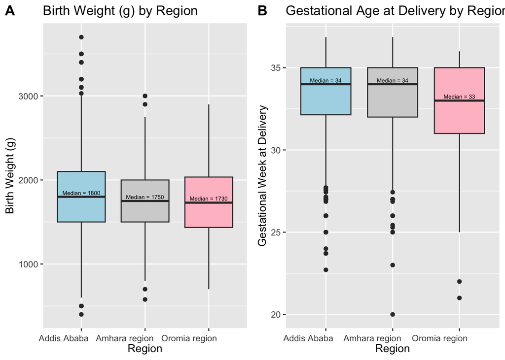

```r
# Define custom colors for each region
region_colors <- c("Addis Ababa" = "lightblue", "Amhara region" = "lightgray", "Oromia region"="pink")

# Plotting Infant birth weight (gram) by region
fig <- ggplot(merged_data, aes(x = region, y = birthweight, fill = region)) +
  geom_boxplot() +
  stat_summary(
    fun = median, geom = "text", aes(label = paste("Median =", round(..y.., 2))),
    vjust = -0.5, position = position_dodge(width = 0.75), size = 2
  ) +
  scale_fill_manual(values = region_colors) +  # Set custom colors
  theme(axis.text.x = element_text(angle = 0, hjust = 0.85, vjust = 0.2), legend.position = "none") +
  labs(
    title = "Birth Weight (g) by Region",
    x = "Region",
    y = "Birth Weight (g)"
  )

# Plotting Infant gestational week at delivery by region
fig.2 <- ggplot(merged_data, aes(x = region, y = gestageweeksatdelivery, fill = region)) +
  geom_boxplot() +
  stat_summary(
    fun = median, geom = "text", aes(label = paste("Median =", round(..y.., 2))),
    vjust = -0.5, position = position_dodge(width = 0.75), size = 2
  ) +
  scale_fill_manual(values = region_colors) +  # Set custom colors
  theme(axis.text.x = element_text(angle = 0, hjust = 0.85, vjust = 0.2), legend.position = "none") +
  labs(
    title = "Gestational Age at Delivery by Region",
    x = "Region",
    y = "Gestational Week at Delivery"
  )

# Graphical representation of infant characteristics
# Saving output
ggsave("Ex.pdf")
ggsave("Ex.tiff", plot = fig)

# Printing the output of figure one + two combined
plot_grid(fig, fig.2, labels = "AUTO")
```

The lowest birth weight and gestational age is in the oromia region.

## Maternal Baseline Characteristics by region

```r
#Maternal Characteristics

merged_data %>%
  select(c(maternalage, firstpreg, educationlevel, occupation, maritalstatus, region)) %>%
  mutate_all(~ifelse(.x == "", NA, .x)) %>%  # Replace empty strings with NA
  tbl_summary(by = region) %>%
  add_p()
```

| **Characteristic** | **Addis Ababa**, N = 3,208<sup>1</sup> | **Amhara region**, N = 1,019<sup>1</sup> | **Oromia region**, N = 692<sup>1</sup> | **p-value**<sup>2</sup> |
| --- | --- | --- | --- | --- |
| maternalage | 26 (23, 30) | 26 (22, 30) | 25 (20, 29) | <0.001 |
| Unknown | 14 | 6 | 1 |  |
| firstpreg | 1,475 (46%) | 451 (44%) | 292 (42%) | 0.2 |
| educationlevel |  |  |  |  |
| Don't know | 21 (0.7%) | 0 (0%) | 2 (0.3%) |  |
| Higher education | 427 (13%) | 153 (15%) | 93 (13%) |  |
| None, able to read and write | 272 (8.5%) | 52 (5.2%) | 25 (3.6%) |  |
| None, not able to read or write | 431 (14%) | 387 (39%) | 226 (33%) |  |
| Primary school | 1,237 (39%) | 203 (20%) | 226 (33%) |  |
| Secondary school | 796 (25%) | 204 (20%) | 120 (17%) |  |
| Unknown | 24 | 20 | 0 |  |
| occupation |  |  |  |  |
| Don't know | 22 (0.7%) | 10 (1.0%) | 1 (0.1%) |  |
| Farmer | 47 (1.5%) | 61 (6.2%) | 45 (6.6%) |  |
| Government or company | 336 (11%) | 117 (12%) | 76 (11%) |  |
| Housewife | 2,184 (69%) | 656 (66%) | 499 (73%) |  |
| Other | 40 (1.3%) | 45 (4.6%) | 24 (3.5%) |  |
| Self-employed | 549 (17%) | 99 (10%) | 38 (5.6%) |  |
| Unknown | 30 | 31 | 9 |  |
| maritalstatus |  |  |  |  |
| Divorced | 19 (0.6%) | 14 (1.4%) | 3 (0.4%) |  |
| Don't know | 7 (0.2%) | 2 (0.2%) | 1 (0.1%) |  |
| Married | 3,092 (97%) | 965 (95%) | 679 (98%) |  |
| Single | 77 (2.4%) | 27 (2.7%) | 8 (1.2%) |  |
| Widowed | 3 (<0.1%) | 3 (0.3%) | 1 (0.1%) |  |
| Unknown | 10 | 8 | 0 |  |

<sup>1</sup> Median (IQR); n (%)  
<sup>2</sup> Kruskal-Wallis rank sum test; Pearson’s Chi-squared test

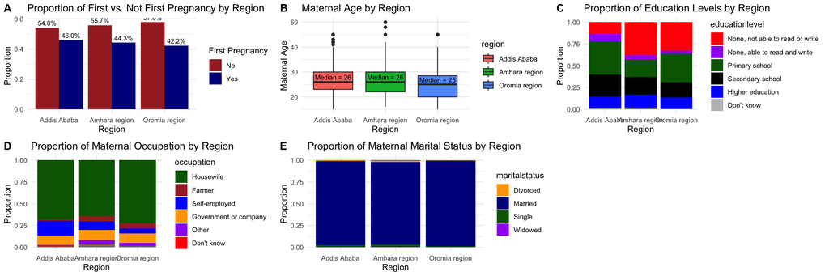

```r
# Calculate proportions of first vs. not first pregnancies by region
proportions_firstpreg <- merged_data %>%
  group_by(region, firstpreg) %>%
  summarize(Count = n()) %>%
  group_by(region) %>%
  mutate(Proportion = Count / sum(Count))

# plotting first vs not first pregnancy by region
fig <-ggplot(proportions_firstpreg, aes(x = region, y = Proportion, fill = factor(firstpreg))) +
  geom_bar(stat = "identity", position = "dodge") +
  geom_text(aes(label = scales::percent(Proportion)),
            position = position_dodge(width = 0.9),
            vjust = -0.5, size = 3) +
  labs(title = "Proportion of First vs. Not First Pregnancy by Region",
       x = "Region",
       y = "Proportion") +
  scale_fill_manual(values = c("1" = "darkblue", "0" = "brown"),
                    name = "First Pregnancy",
                    labels = c("1" = "Yes", "0" = "No")) +
  theme_minimal()
# Maternal characteristic (maternal age by region)
fig.2 <-ggplot(merged_data, aes(x = region, y = maternalage, fill = region)) +
  geom_boxplot() +
  stat_summary(fun = median, geom = "text", aes(label = paste("Median =", round(..y.., 2))),
               vjust = -0.5, position = position_dodge(width = 0.75), size = 3) +
  labs(title = "Maternal Age by Region",
       x = "Region",
       y = "Maternal Age") +
  theme_minimal()

# maternal Education
proportions_education <- merged_data %>%
  group_by(region,educationlevel ) %>%
  summarize(Count = n()) %>%
  group_by(region) %>%
  mutate(Proportion = Count / sum(Count))

# plotting it by region
#  convert educational level to a factor and reorder
proportions_education$educationlevel <- factor(proportions_education$educationlevel,
                                               levels = c("None, not able to read or write",
                                                          "None, able to read and write",
                                                          "Primary school",
                                                          "Secondary school",
                                                          "Higher education",
                                                          "Don't know"))

# create the ggplot with the modified data
fig.3 <-ggplot(proportions_education, aes(x = region, y = Proportion, fill = educationlevel)) +
  geom_bar(stat = "identity", position = "stack") +
  labs(title = "Proportion of Education Levels by Region",
       x = "Region",
       y = "Proportion") +
  scale_fill_manual(values = c("Don't know" = "gray", "Higher education" = "blue",
                               "None, able to read and write" = "purple",
                               "None, not able to read or write" = "red",
                               "Primary school" = "darkgreen", "Secondary school" = "black")) +
  theme_minimal()

# maternal occupation
proportions_work <- merged_data %>%
  group_by(region,occupation) %>%
  summarize(Count = n()) %>%
  group_by(region) %>%
  mutate(Proportion = Count / sum(Count))
#  convert occupation level to a factor and reorder
proportions_work$occupation <- factor(proportions_work$occupation,
                                               levels = c("Housewife",
                                                           "Farmer",
                                                          "Self-employed" ,
                                                           "Government or company",
                                                          "Other",
                                                          "Don't know"))

# plotting maternal occupation by region
fig.4 <-ggplot(proportions_work, aes(x = region, y = Proportion, fill = occupation)) +
  geom_bar(stat = "identity", position = "stack") +
  labs(title = "Proportion of Maternal Occupation by Region",
       x = "Region",
       y = "Proportion") +
  scale_fill_manual(values = c(
    "Self-employed" = "blue",
    "Housewife" = "darkgreen",
    "Don't know" = "red",
    "Other" = "purple",
    "Government or company" = "orange",
    "Farmer" = "brown"
  )) +
  theme_minimal()

# maternal marital status
proportions_married <- merged_data %>%
  group_by(region,maritalstatus) %>%
  summarize(Count = n()) %>%
  group_by(region) %>%
  mutate(Proportion = Count / sum(Count))
#  convert marital status level to a factor and reorder
proportions_work$occupation <- factor(proportions_work$occupation,
                                               levels = c("Married",
                                                           "Farmer",
                                                          "Widowed" ,
                                                           "Divorced",
                                                          "Single" ,
                                                          "Don't know"))


# Create a bar plot of maternal marital status by region
fig.5 <-ggplot(proportions_married, aes(x = region, y = Proportion, fill = maritalstatus)) +
  geom_bar(stat = "identity", position = "stack") +
  labs(title = "Proportion of Maternal Marital Status by Region",
       x = "Region",
       y = "Proportion") +
  scale_fill_manual(values = c(
    "Married" = "darkblue",
    "Single" = "darkgreen",
    "Don't Know" = "red",
    "Widowed" = "purple",
    "Divorced" = "orange"
  )) +
  theme_minimal()

cowplot::plot_grid(fig, fig.2, fig.3, fig.4,fig.5,labels = "AUTO")
```

There is a statistically significant difference in maternal age by region.

## Mortality by Region

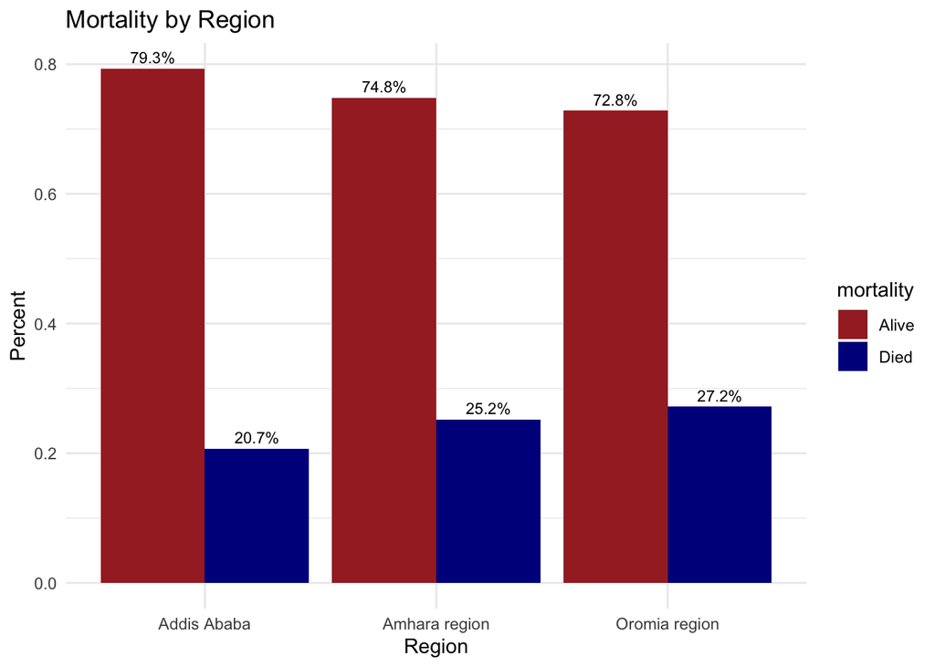

```r
#looking at # of mortality by region
proportions_mortality <- merged_data %>%
  group_by(region,mortality) %>%
  summarize(Count = n()) %>%
  group_by(region) %>%
  mutate(Proportion = Count / sum(Count))
# plotting mortality by region
ggplot(proportions_mortality, aes(x = region, y = Proportion, fill = factor(mortality))) +
  geom_bar(stat = "identity", position = "dodge") +
  geom_text(aes(label = scales::percent(Proportion)),
            position = position_dodge(width = 0.9),
            vjust = -0.5, size = 3) +
  labs(title = "Mortality by Region",
       x = "Region",
       y = "Percent") +
  scale_fill_manual(values = c("1" = "darkblue", "0" = "brown"),
                    name = "mortality",
                    labels = c("1" = "Died", "0" = "Alive")) +
  theme_minimal()
```

```r
#statistically testing region vs mortality (chi2)
# create a table with the needed varaibles
mortality.chi = table(merged_data$region, merged_data$mortality)
print(mortality.chi)
```

```
                   0    1
  Addis Ababa   2544  664
  Amhara region  762  257
  Oromia region  504  188
```

```r
#performe the chi-square test
print(chisq.test((mortality.chi)))
```

```
    Pearson's Chi-squared test

data:  (mortality.chi)
X-squared = 18.911, df = 2, p-value = 7.824e-05
```

There is an association between mortality and region.

## **Main Model**

```r
# adding all confounder's in the modell
glm_fit_confounding <-glm(mortality ~ region + maternalage + sex + firstpreg + birthweight + gestageweeksatdelivery + maritalstatus + occupation, data = merged_data, family =binomial)
summary(glm_fit_confounding)
```

```
Call:
glm(formula = mortality ~ region + maternalage + sex + firstpreg +
    birthweight + gestageweeksatdelivery + maritalstatus + occupation,
    family = binomial, data = merged_data)

Coefficients:
                                  Estimate Std. Error z value Pr(>|z|)
(Intercept)                     11.4668738  1.9736750   5.810 6.25e-09 ***
regionAmhara region              0.1167712  0.1015921   1.149   0.2504
regionOromia region              0.1933644  0.1156235   1.672   0.0945 .
maternalage                      0.0115072  0.0084160   1.367   0.1715
sexFemale                       -0.3227279  0.4596990  -0.702   0.4827
sexMale                         -0.0021557  0.4585952  -0.005   0.9962
firstpreg                        0.2017099  0.0889504   2.268   0.0233 *
birthweight                     -0.0013991  0.0001279 -10.940  < 2e-16 ***
gestageweeksatdelivery          -0.3529115  0.0224963 -15.688  < 2e-16 ***
maritalstatusDivorced            0.3213825  1.8054313   0.178   0.8587
maritalstatusDon't know          0.1402141  1.9570561   0.072   0.9429
maritalstatusMarried             0.1456598  1.7582373   0.083   0.9340
maritalstatusSingle             -0.0635454  1.7763333  -0.036   0.9715
maritalstatusWidowed             0.3078536  2.0106656   0.153   0.8783
occupationDon't know             1.0706631  0.6208758   1.724   0.0846 .
occupationFarmer                 0.9054602  0.4615223   1.962   0.0498 *
occupationGovernment or company  0.6088845  0.4314481   1.411   0.1582
occupationHousewife              0.7944348  0.4142829   1.918   0.0552 .
occupationOther                  0.9512471  0.4835720   1.967   0.0492 *
occupationSelf-employed          0.7808998  0.4264343   1.831   0.0671 .
---
Signif. codes:  0 '***' 0.001 '**' 0.01 '*' 0.05 '.' 0.1 ' ' 1

(Dispersion parameter for binomial family taken to be 1)

    Null deviance: 5130.3  on 4803  degrees of freedom
Residual deviance: 3919.4  on 4784  degrees of freedom
  (115 observations deleted due to missingness)
AIC: 3959.4

Number of Fisher Scoring iterations: 5
```

```r
# association between gestational age, weight, and firstpreg vs region
glm_fit_confounding1 <-lm(gestageweeksatdelivery ~ region + maternalage + sex + firstpreg + birthweight + mortality + maritalstatus + occupation, data = merged_data, family =binomial)
summary(glm_fit_confounding1)
```

```
Call:
lm(formula = gestageweeksatdelivery ~ region + maternalage +
    sex + firstpreg + birthweight + mortality + maritalstatus +
    occupation, data = merged_data, family = binomial)

Residuals:
     Min       1Q   Median       3Q      Max
-13.6700  -1.0070   0.0775   1.1120   6.2434

Coefficients:
                                  Estimate Std. Error t value Pr(>|t|)
(Intercept)                      2.895e+01  9.253e-01  31.291  < 2e-16 ***
regionAmhara region             -2.977e-01  6.260e-02  -4.756 2.03e-06 ***
regionOromia region             -3.636e-01  7.363e-02  -4.938 8.17e-07 ***
maternalage                      6.550e-03  5.116e-03   1.280    0.201
sexFemale                        3.830e-02  2.773e-01   0.138    0.890
sexMale                         -9.040e-02  2.769e-01  -0.327    0.744
firstpreg                        3.058e-01  5.344e-02   5.721 1.12e-08 ***
birthweight                      2.780e-03  5.875e-05  47.317  < 2e-16 ***
mortality                       -1.409e+00  6.423e-02 -21.930  < 2e-16 ***
maritalstatusDivorced           -5.724e-01  9.038e-01  -0.633    0.527
maritalstatusDon't know         -4.368e-01  1.010e+00  -0.432    0.665
maritalstatusMarried            -4.928e-01  8.581e-01  -0.574    0.566
maritalstatusSingle             -6.017e-01  8.729e-01  -0.689    0.491
maritalstatusWidowed            -9.527e-01  1.070e+00  -0.890    0.373
occupationDon't know             2.352e-01  3.766e-01   0.625    0.532
occupationFarmer                 1.888e-01  2.680e-01   0.705    0.481
occupationGovernment or company  2.183e-01  2.411e-01   0.905    0.365
occupationHousewife              1.195e-01  2.312e-01   0.517    0.605
occupationOther                  2.051e-01  2.816e-01   0.728    0.467
occupationSelf-employed          1.552e-01  2.390e-01   0.649    0.516
---
Signif. codes:  0 '***' 0.001 '**' 0.01 '*' 0.05 '.' 0.1 ' ' 1

Residual standard error: 1.692 on 4784 degrees of freedom
  (115 observations deleted due to missingness)
Multiple R-squared:  0.4824,    Adjusted R-squared:  0.4804
F-statistic: 234.7 on 19 and 4784 DF,  p-value: < 2.2e-16
```

```r
glm_fit_confounding2 <-lm(birthweight ~ region + maternalage + sex + firstpreg + gestageweeksatdelivery + mortality + maritalstatus + occupation, data = merged_data, family =binomial)
summary(glm_fit_confounding2)
```

```
Call:
lm(formula = birthweight ~ region + maternalage + sex + firstpreg +
    gestageweeksatdelivery + mortality + maritalstatus + occupation,
    data = merged_data, family = binomial)

Residuals:
     Min       1Q   Median       3Q      Max
-1212.68  -215.11   -18.97   199.46  2461.58

Coefficients:
                                  Estimate Std. Error t value Pr(>|t|)
(Intercept)                     -2044.7572   204.1482 -10.016  < 2e-16 ***
regionAmhara region                21.4929    12.7411   1.687  0.09169 .
regionOromia region                19.6460    14.9902   1.311  0.19006
maternalage                         0.6338     1.0392   0.610  0.54198
sexFemale                         -84.9835    56.3145  -1.509  0.13134
sexMale                            -5.6462    56.2350  -0.100  0.92003
firstpreg                         -40.6192    10.8760  -3.735  0.00019 ***
gestageweeksatdelivery            114.6811     2.4237  47.317  < 2e-16 ***
mortality                        -143.2018    13.5277 -10.586  < 2e-16 ***
maritalstatusDivorced             -60.2839   183.5693  -0.328  0.74262
maritalstatusDon't know            68.4005   205.1972   0.333  0.73889
maritalstatusMarried               21.0498   174.2899   0.121  0.90387
maritalstatusSingle               -18.5873   177.2976  -0.105  0.91651
maritalstatusWidowed              -32.7779   217.3869  -0.151  0.88015
occupationDon't know              -31.6672    76.4910  -0.414  0.67889
occupationFarmer                    2.8930    54.4400   0.053  0.95762
occupationGovernment or company    38.8542    48.9755   0.793  0.42762
occupationHousewife                57.0078    46.9579   1.214  0.22480
occupationOther                    47.1911    57.2007   0.825  0.40941
occupationSelf-employed            28.7300    48.5469   0.592  0.55401
---
Signif. codes:  0 '***' 0.001 '**' 0.01 '*' 0.05 '.' 0.1 ' ' 1

Residual standard error: 343.6 on 4784 degrees of freedom
  (115 observations deleted due to missingness)
Multiple R-squared:  0.4427,    Adjusted R-squared:  0.4405
F-statistic:   200 on 19 and 4784 DF,  p-value: < 2.2e-16
```

```r
glm_fit_confounding3 <-glm(firstpreg ~ region + maternalage + sex + birthweight + gestageweeksatdelivery + mortality + maritalstatus + occupation, data = merged_data, family =binomial)
summary(glm_fit_confounding3)
```

```
Call:
glm(formula = firstpreg ~ region + maternalage + sex + birthweight +
    gestageweeksatdelivery + mortality + maritalstatus + occupation,
    family = binomial, data = merged_data)

Coefficients:
                                  Estimate Std. Error z value Pr(>|z|)
(Intercept)                      2.942e+00  1.409e+00   2.088 0.036778 *
regionAmhara region             -9.791e-02  8.306e-02  -1.179 0.238517
regionOromia region             -4.013e-01  9.655e-02  -4.156 3.24e-05 ***
maternalage                     -1.797e-01  7.351e-03 -24.449  < 2e-16 ***
sexFemale                       -3.574e-01  3.571e-01  -1.001 0.317000
sexMale                         -2.409e-01  3.566e-01  -0.675 0.499360
birthweight                     -3.447e-04  9.356e-05  -3.684 0.000229 ***
gestageweeksatdelivery           1.072e-01  1.907e-02   5.620 1.91e-08 ***
mortality                        1.812e-01  8.825e-02   2.054 0.040009 *
maritalstatusDivorced           -3.432e-01  1.286e+00  -0.267 0.789496
maritalstatusDon't know         -6.977e-01  1.420e+00  -0.491 0.623159
maritalstatusMarried            -9.743e-02  1.231e+00  -0.079 0.936934
maritalstatusSingle              3.620e-01  1.251e+00   0.289 0.772333
maritalstatusWidowed            -2.675e-01  1.479e+00  -0.181 0.856526
occupationDon't know            -5.593e-01  5.048e-01  -1.108 0.267859
occupationFarmer                -1.318e+00  3.765e-01  -3.501 0.000464 ***
occupationGovernment or company -7.477e-01  3.342e-01  -2.237 0.025276 *
occupationHousewife             -1.116e+00  3.231e-01  -3.455 0.000550 ***
occupationOther                 -5.048e-01  3.892e-01  -1.297 0.194641
occupationSelf-employed         -9.106e-01  3.323e-01  -2.740 0.006140 **
---
Signif. codes:  0 '***' 0.001 '**' 0.01 '*' 0.05 '.' 0.1 ' ' 1

(Dispersion parameter for binomial family taken to be 1)

    Null deviance: 6607.2  on 4803  degrees of freedom
Residual deviance: 5741.2  on 4784  degrees of freedom
  (115 observations deleted due to missingness)
AIC: 5781.2

Number of Fisher Scoring iterations: 4
```

Mortality is significantly associated with parity, gestational age, and birth weight.

### **Stratification by Parity**

```r
#stratification of first vs not first pregnancy
# Subset data for firstpreg == 0
data_firstpreg_0 <- merged_data[merged_data$firstpreg == 0, ]

# Subset data for firstpreg == 1
data_firstpreg_1 <- merged_data[merged_data$firstpreg == 1, ]

# Analysis for first vs not first pregnancy stratified
# Fit logistic regression model for firstpreg == 0
model_firstpreg_0 <- glm(mortality ~ region + maternalage +  birthweight + gestageweeksatdelivery + maritalstatus + occupation, data = data_firstpreg_0 ,family = binomial)
summary(model_firstpreg_0)
```

```
Call:
glm(formula = mortality ~ region + maternalage + birthweight +
    gestageweeksatdelivery + maritalstatus + occupation, family = binomial,
    data = data_firstpreg_0)

Coefficients:
                                  Estimate Std. Error z value Pr(>|z|)
(Intercept)                      1.156e+01  3.134e+00   3.688 0.000226 ***
regionAmhara region              1.105e-01  1.370e-01   0.807 0.419859
regionOromia region              1.238e-01  1.539e-01   0.804 0.421363
maternalage                      6.928e-03  1.077e-02   0.643 0.520184
birthweight                     -1.521e-03  1.702e-04  -8.937  < 2e-16 ***
gestageweeksatdelivery          -3.093e-01  2.947e-02 -10.495  < 2e-16 ***
maritalstatusDivorced           -1.027e+00  3.064e+00  -0.335 0.737618
maritalstatusDon't know         -1.443e+01  3.344e+02  -0.043 0.965577
maritalstatusMarried            -1.568e+00  3.014e+00  -0.520 0.602895
maritalstatusSingle             -1.862e+00  3.049e+00  -0.610 0.541550
maritalstatusWidowed            -1.928e+00  3.244e+00  -0.594 0.552262
occupationDon't know             1.574e+00  1.075e+00   1.464 0.143207
occupationFarmer                 1.462e+00  8.631e-01   1.694 0.090196 .
occupationGovernment or company  9.760e-01  8.466e-01   1.153 0.248968
occupationHousewife              1.154e+00  8.303e-01   1.390 0.164482
occupationOther                  1.044e+00  9.372e-01   1.115 0.265053
occupationSelf-employed          1.328e+00  8.416e-01   1.577 0.114710
---
Signif. codes:  0 '***' 0.001 '**' 0.01 '*' 0.05 '.' 0.1 ' ' 1

(Dispersion parameter for binomial family taken to be 1)

    Null deviance: 2816.7  on 2652  degrees of freedom
Residual deviance: 2164.0  on 2636  degrees of freedom
  (48 observations deleted due to missingness)
AIC: 2198

Number of Fisher Scoring iterations: 13
```

```r
# Fit logistic regression model for firstpreg == 1
model_firstpreg_1 <- glm(mortality ~ region + maternalage +  birthweight + gestageweeksatdelivery + maritalstatus + occupation, data = data_firstpreg_1 ,family = binomial)
summary(model_firstpreg_1)
```

```
Call:
glm(formula = mortality ~ region + maternalage + birthweight +
    gestageweeksatdelivery + maritalstatus + occupation, family = binomial,
    data = data_firstpreg_1)

Coefficients:
                                  Estimate Std. Error z value Pr(>|z|)
(Intercept)                      1.934e+00  3.681e+02   0.005   0.9958
regionAmhara region              1.599e-01  1.560e-01   1.025   0.3052
regionOromia region              3.394e-01  1.781e-01   1.906   0.0567 .
maternalage                      2.279e-02  1.380e-02   1.652   0.0986 .
birthweight                     -1.125e-03  1.914e-04  -5.878 4.15e-09 ***
gestageweeksatdelivery          -4.171e-01  3.487e-02 -11.963  < 2e-16 ***
maritalstatusDivorced            1.070e+01  3.681e+02   0.029   0.9768
maritalstatusDon't know          1.256e+01  3.681e+02   0.034   0.9728
maritalstatusMarried             1.122e+01  3.681e+02   0.030   0.9757
maritalstatusSingle              1.110e+01  3.681e+02   0.030   0.9760
maritalstatusWidowed             1.230e+01  3.681e+02   0.033   0.9734
occupationDon't know             8.263e-01  8.161e-01   1.013   0.3113
occupationFarmer                 3.377e-01  6.317e-01   0.535   0.5930
occupationGovernment or company  4.794e-01  5.249e-01   0.913   0.3610
occupationHousewife              6.999e-01  4.942e-01   1.416   0.1567
occupationOther                  9.845e-01  5.822e-01   1.691   0.0909 .
occupationSelf-employed          4.314e-01  5.176e-01   0.833   0.4046
---
Signif. codes:  0 '***' 0.001 '**' 0.01 '*' 0.05 '.' 0.1 ' ' 1

(Dispersion parameter for binomial family taken to be 1)

    Null deviance: 2313.3  on 2150  degrees of freedom
Residual deviance: 1751.5  on 2134  degrees of freedom
  (67 observations deleted due to missingness)
AIC: 1785.5

Number of Fisher Scoring iterations: 12
```

Regardless of parity status, mortality is significantly associated with birth weight and gestational age.

### **Stratification by Gestational Age**

```r
#stratifying gestational age
# Categorize gestageweeksatdelivery
merged_data$gestation_category <- cut(
  merged_data$gestageweeksatdelivery,
  breaks = c(0, 28, 31, 34, 36, Inf),
  labels = c("<28 weeks", "28 to 31 weeks", "32 to 34 weeks", "35 to <36 weeks", ">=36 weeks"),
  include.lowest = TRUE
)
# Verify the new variable
head(merged_data$gestation_category)
```

```
[1] 32 to 34 weeks  32 to 34 weeks  35 to <36 weeks 35 to <36 weeks
[5] >=36 weeks      >=36 weeks
5 Levels: <28 weeks 28 to 31 weeks 32 to 34 weeks ... >=36 weeks
```

```r
# Create stratified datasets gestational age
# Access the subset for "<28 weeks"
subset_less_than_28 <- merged_data[merged_data$gestation_category == "<28 weeks", ]
# Fit logistic regression model for <28 weeks
model_less28 <- glm(mortality ~ region + maternalage + birthweight + firstpreg + maritalstatus + occupation, data = subset_less_than_28, family = binomial)
summary(model_less28 )
```

```
Call:
glm(formula = mortality ~ region + maternalage + birthweight +
    firstpreg + maritalstatus + occupation, family = binomial,
    data = subset_less_than_28)

Coefficients:
                                  Estimate Std. Error z value Pr(>|z|)
(Intercept)                      1.767e+01  6.523e+03   0.003    0.998
regionAmhara region             -3.692e-01  4.776e-01  -0.773    0.439
regionOromia region             -3.295e-01  7.575e-01  -0.435    0.664
maternalage                      2.628e-02  4.606e-02   0.571    0.568
birthweight                     -9.202e-04  6.842e-04  -1.345    0.179
firstpreg                        9.959e-02  4.684e-01   0.213    0.832
maritalstatusDivorced            1.151e-01  7.977e+03   0.000    1.000
maritalstatusMarried            -1.716e+01  6.523e+03  -0.003    0.998
maritalstatusSingle             -1.737e+01  6.523e+03  -0.003    0.998
maritalstatusWidowed            -8.293e-01  9.224e+03   0.000    1.000
occupationDon't know             1.848e+01  4.610e+03   0.004    0.997
occupationFarmer                 1.860e+01  2.458e+03   0.008    0.994
occupationGovernment or company  1.745e+00  1.223e+00   1.427    0.154
occupationHousewife              1.449e+00  1.079e+00   1.343    0.179
occupationOther                  1.881e+01  2.873e+03   0.007    0.995
occupationSelf-employed          8.451e-01  1.180e+00   0.716    0.474

(Dispersion parameter for binomial family taken to be 1)

    Null deviance: 159.59  on 172  degrees of freedom
Residual deviance: 145.77  on 157  degrees of freedom
  (3 observations deleted due to missingness)
AIC: 177.77

Number of Fisher Scoring iterations: 17
```

```r
# Access the subset for "28 to 31 weeks"
subset_28_to_31 <- merged_data[merged_data$gestation_category == "28 to 31 weeks", ]
model_28_31 <- glm(mortality ~ region + maternalage + birthweight +  firstpreg + maritalstatus + occupation, data = subset_28_to_31, family = binomial)
summary(model_28_31)
```

```
Call:
glm(formula = mortality ~ region + maternalage + birthweight +
    firstpreg + maritalstatus + occupation, family = binomial,
    data = subset_28_to_31)

Coefficients:
                                  Estimate Std. Error z value Pr(>|z|)
(Intercept)                      2.297e+00  1.129e+00   2.035  0.04189 *
regionAmhara region             -1.217e-01  1.998e-01  -0.609  0.54237
regionOromia region             -1.926e-01  1.979e-01  -0.973  0.33034
maternalage                      1.751e-02  1.618e-02   1.082  0.27929
birthweight                     -2.322e-03  2.744e-04  -8.463  < 2e-16 ***
firstpreg                        5.638e-01  1.788e-01   3.153  0.00162 **
maritalstatusDon't know          1.369e+01  3.652e+02   0.037  0.97009
maritalstatusMarried             3.246e-01  6.541e-01   0.496  0.61973
maritalstatusSingle              1.248e-01  7.987e-01   0.156  0.87589
maritalstatusWidowed             7.362e-01  1.586e+00   0.464  0.64251
occupationDon't know            -4.224e-01  1.093e+00  -0.386  0.69918
occupationFarmer                -1.294e-02  8.230e-01  -0.016  0.98746
occupationGovernment or company -2.360e-01  7.583e-01  -0.311  0.75562
occupationHousewife              1.679e-01  7.147e-01   0.235  0.81424
occupationOther                  5.787e-01  8.544e-01   0.677  0.49817
occupationSelf-employed         -1.566e-01  7.426e-01  -0.211  0.83294
---
Signif. codes:  0 '***' 0.001 '**' 0.01 '*' 0.05 '.' 0.1 ' ' 1

(Dispersion parameter for binomial family taken to be 1)

    Null deviance: 1065.46  on 770  degrees of freedom
Residual deviance:  961.31  on 755  degrees of freedom
  (19 observations deleted due to missingness)
AIC: 993.31

Number of Fisher Scoring iterations: 12
```

```r
# Access the subset for "32 to 34 weeks"
subset_32_to_34 <- merged_data[merged_data$gestation_category == "32 to 34 weeks", ]
model_32_to_34 <- glm(mortality ~ region + maternalage + birthweight +  firstpreg + maritalstatus + occupation, data = subset_32_to_34, family = binomial)
summary(model_32_to_34)
```

```
Call:
glm(formula = mortality ~ region + maternalage + birthweight +
    firstpreg + maritalstatus + occupation, family = binomial,
    data = subset_32_to_34)

Coefficients:
                                  Estimate Std. Error z value Pr(>|z|)
(Intercept)                      1.726e+00  1.010e+00   1.709   0.0875 .
regionAmhara region              3.037e-01  1.497e-01   2.029   0.0425 *
regionOromia region              3.436e-01  1.886e-01   1.822   0.0684 .
maternalage                      5.448e-04  1.324e-02   0.041   0.9672
birthweight                     -1.710e-03  1.925e-04  -8.884   <2e-16 ***
firstpreg                        4.139e-02  1.344e-01   0.308   0.7581
maritalstatusDon't know         -1.422e+01  4.367e+02  -0.033   0.9740
maritalstatusMarried            -1.002e+00  6.144e-01  -1.631   0.1028
maritalstatusSingle             -2.346e+00  9.577e-01  -2.449   0.0143 *
maritalstatusWidowed             1.456e+01  8.827e+02   0.016   0.9868
occupationDon't know            -3.212e-01  1.305e+00  -0.246   0.8056
occupationFarmer                 6.678e-01  7.012e-01   0.952   0.3409
occupationGovernment or company  4.262e-01  6.638e-01   0.642   0.5208
occupationHousewife              5.786e-01  6.382e-01   0.907   0.3646
occupationOther                  4.640e-01  7.634e-01   0.608   0.5433
occupationSelf-employed          6.139e-01  6.560e-01   0.936   0.3494
---
Signif. codes:  0 '***' 0.001 '**' 0.01 '*' 0.05 '.' 0.1 ' ' 1

(Dispersion parameter for binomial family taken to be 1)

    Null deviance: 1757.5  on 1769  degrees of freedom
Residual deviance: 1647.8  on 1754  degrees of freedom
  (49 observations deleted due to missingness)
AIC: 1679.8

Number of Fisher Scoring iterations: 13
```

```r
# Access the subset for "35 to <36 weeks"
subset_35_to_less_than_36 <- merged_data[merged_data$gestation_category == "35 to <36 weeks", ]
model_35_to_less_than_36  <- glm(mortality ~ region + maternalage + birthweight + firstpreg + maritalstatus + occupation, data = subset_35_to_less_than_36 , family = binomial)
summary(model_35_to_less_than_36 )
```

```
Call:
glm(formula = mortality ~ region + maternalage + birthweight +
    firstpreg + maritalstatus + occupation, family = binomial,
    data = subset_35_to_less_than_36)

Coefficients:
                                  Estimate Std. Error z value Pr(>|z|)
(Intercept)                     -2.990e+01  1.228e+03  -0.024   0.9806
regionAmhara region              1.246e-01  2.222e-01   0.561   0.5749
regionOromia region              4.143e-01  2.301e-01   1.800   0.0718 .
maternalage                      1.906e-02  1.616e-02   1.179   0.2383
birthweight                     -1.054e-03  2.288e-04  -4.607 4.08e-06 ***
firstpreg                        1.498e-01  1.765e-01   0.849   0.3958
maritalstatusDivorced            6.009e-01  1.333e+03   0.000   0.9996
maritalstatusDon't know          2.983e-01  1.550e+03   0.000   0.9998
maritalstatusMarried             1.480e+01  1.099e+03   0.013   0.9893
maritalstatusSingle              1.534e+01  1.099e+03   0.014   0.9889
maritalstatusWidowed             4.140e-01  1.749e+03   0.000   0.9998
occupationDon't know             1.565e+01  5.468e+02   0.029   0.9772
occupationFarmer                 1.451e+01  5.468e+02   0.027   0.9788
occupationGovernment or company  1.407e+01  5.468e+02   0.026   0.9795
occupationHousewife              1.418e+01  5.468e+02   0.026   0.9793
occupationOther                  1.373e+01  5.468e+02   0.025   0.9800
occupationSelf-employed          1.446e+01  5.468e+02   0.026   0.9789
---
Signif. codes:  0 '***' 0.001 '**' 0.01 '*' 0.05 '.' 0.1 ' ' 1

(Dispersion parameter for binomial family taken to be 1)

    Null deviance: 1153.7  on 1896  degrees of freedom
Residual deviance: 1113.4  on 1880  degrees of freedom
  (42 observations deleted due to missingness)
AIC: 1147.4

Number of Fisher Scoring iterations: 15
```

```r
# Access the subset for ">=36 weeks"
subset_greater_than_equal_36 <- merged_data[merged_data$gestation_category == ">=36 weeks", ]
model_greater_than_equal_36 <- glm(mortality ~ region + maternalage + birthweight + firstpreg + maritalstatus + occupation, data = subset_35_to_less_than_36 , family = binomial)
summary(model_greater_than_equal_36)
```

```
Call:
glm(formula = mortality ~ region + maternalage + birthweight +
    firstpreg + maritalstatus + occupation, family = binomial,
    data = subset_35_to_less_than_36)

Coefficients:
                                  Estimate Std. Error z value Pr(>|z|)
(Intercept)                     -2.990e+01  1.228e+03  -0.024   0.9806
regionAmhara region              1.246e-01  2.222e-01   0.561   0.5749
regionOromia region              4.143e-01  2.301e-01   1.800   0.0718 .
maternalage                      1.906e-02  1.616e-02   1.179   0.2383
birthweight                     -1.054e-03  2.288e-04  -4.607 4.08e-06 ***
firstpreg                        1.498e-01  1.765e-01   0.849   0.3958
maritalstatusDivorced            6.009e-01  1.333e+03   0.000   0.9996
maritalstatusDon't know          2.983e-01  1.550e+03   0.000   0.9998
maritalstatusMarried             1.480e+01  1.099e+03   0.013   0.9893
maritalstatusSingle              1.534e+01  1.099e+03   0.014   0.9889
maritalstatusWidowed             4.140e-01  1.749e+03   0.000   0.9998
occupationDon't know             1.565e+01  5.468e+02   0.029   0.9772
occupationFarmer                 1.451e+01  5.468e+02   0.027   0.9788
occupationGovernment or company  1.407e+01  5.468e+02   0.026   0.9795
occupationHousewife              1.418e+01  5.468e+02   0.026   0.9793
occupationOther                  1.373e+01  5.468e+02   0.025   0.9800
occupationSelf-employed          1.446e+01  5.468e+02   0.026   0.9789
---
Signif. codes:  0 '***' 0.001 '**' 0.01 '*' 0.05 '.' 0.1 ' ' 1

(Dispersion parameter for binomial family taken to be 1)

    Null deviance: 1153.7  on 1896  degrees of freedom
Residual deviance: 1113.4  on 1880  degrees of freedom
  (42 observations deleted due to missingness)
AIC: 1147.4

Number of Fisher Scoring iterations: 15
```

### **Stratification by Birthweight**

```r
#stratifying birthweight (in grams)
# Categorize gestageweeksatdelivery
# Define the breaks and labels
breaks_birthweight <- c(-Inf, 1000, 1500, 2000, Inf)
labels_birthweight <- c("<1000", "1000 to <1500", "1500 to <2000", ">=2000")

# Create a new categorical variable 'birthweight_category'
merged_data$birthweight_category <- cut(merged_data$birthweight, breaks = breaks_birthweight, labels = labels_birthweight, include.lowest = TRUE)

# Display the first few rows to verify the new variable
head(merged_data[c("birthweight", "birthweight_category")])
```

```
  birthweight birthweight_category
1        2000        1500 to <2000
2        2300               >=2000
3        2300               >=2000
4        2500               >=2000
5        1900        1500 to <2000
6        2000        1500 to <2000
```

```r
# Create a new categorical variable 'birthweight_category'
merged_data$birthweight_category <- cut(merged_data$birthweight, breaks = breaks_birthweight, labels = labels_birthweight, include.lowest = TRUE)

# Display the first few rows to verify the new variable
head(merged_data[c("birthweight", "birthweight_category")])
```

```
  birthweight birthweight_category
1        2000        1500 to <2000
2        2300               >=2000
3        2300               >=2000
4        2500               >=2000
5        1900        1500 to <2000
6        2000        1500 to <2000
```

```r
# Create subset for "<1000"
subset_less_than_1000 <- subset(merged_data, birthweight_category == "<1000")
model_less_than_1000 <- glm(mortality ~ region + maternalage + gestageweeksatdelivery + firstpreg + maritalstatus + occupation, data = subset_less_than_1000 , family = binomial)
summary(model_less_than_1000)
```

```
Call:
glm(formula = mortality ~ region + maternalage + gestageweeksatdelivery +
    firstpreg + maritalstatus + occupation, family = binomial,
    data = subset_less_than_1000)

Coefficients:
                                  Estimate Std. Error z value Pr(>|z|)
(Intercept)                      2.377e+01  1.932e+03   0.012   0.9902
regionAmhara region             -2.041e-01  4.615e-01  -0.442   0.6584
regionOromia region              1.405e+00  8.053e-01   1.745   0.0811 .
maternalage                     -7.635e-03  3.413e-02  -0.224   0.8230
gestageweeksatdelivery          -2.606e-01  6.298e-02  -4.137 3.52e-05 ***
firstpreg                        3.788e-01  3.396e-01   1.115   0.2647
maritalstatusMarried            -1.642e+01  1.932e+03  -0.008   0.9932
maritalstatusSingle             -1.191e-01  2.454e+03   0.000   1.0000
maritalstatusWidowed            -5.384e-01  4.403e+03   0.000   0.9999
occupationDon't know             1.723e+01  1.823e+03   0.009   0.9925
occupationFarmer                 5.517e-01  1.474e+00   0.374   0.7081
occupationGovernment or company  1.620e+00  1.350e+00   1.200   0.2301
occupationHousewife              1.632e+00  1.296e+00   1.259   0.2079
occupationOther                  9.487e-01  1.784e+00   0.532   0.5949
occupationSelf-employed          1.613e+00  1.341e+00   1.203   0.2288
---
Signif. codes:  0 '***' 0.001 '**' 0.01 '*' 0.05 '.' 0.1 ' ' 1

(Dispersion parameter for binomial family taken to be 1)

    Null deviance: 298.06  on 278  degrees of freedom
Residual deviance: 262.22  on 264  degrees of freedom
  (1 observation deleted due to missingness)
AIC: 292.22

Number of Fisher Scoring iterations: 16
```

```r
# Create subset for "1000 to <1500"
subset_1000_to_1500 <- subset(merged_data, birthweight_category == "1000 to <1500")
model_1000_to_1500 <- glm(mortality ~ region + maternalage + gestageweeksatdelivery + firstpreg + maritalstatus + occupation, data = subset_1000_to_1500  , family = binomial)
summary(model_1000_to_1500 )
```

```
Call:
glm(formula = mortality ~ region + maternalage + gestageweeksatdelivery +
    firstpreg + maritalstatus + occupation, family = binomial,
    data = subset_1000_to_1500)

Coefficients:
                                Estimate Std. Error z value Pr(>|z|)
(Intercept)                     11.26265    2.66071   4.233 2.31e-05 ***
regionAmhara region              0.21867    0.16256   1.345    0.179
regionOromia region              0.09996    0.18241   0.548    0.584
maternalage                      0.02079    0.01341   1.550    0.121
gestageweeksatdelivery          -0.38050    0.03332 -11.419  < 2e-16 ***
firstpreg                        0.04864    0.14307   0.340    0.734
maritalstatusDivorced            0.05373    2.42210   0.022    0.982
maritalstatusDon't know          0.06572    2.75421   0.024    0.981
maritalstatusMarried            -0.52381    2.34732  -0.223    0.823
maritalstatusSingle             -0.57355    2.37355  -0.242    0.809
maritalstatusWidowed            -1.08649    2.69738  -0.403    0.687
occupationDon't know            -0.41017    0.91471  -0.448    0.654
occupationFarmer                 0.48125    0.61417   0.784    0.433
occupationGovernment or company  0.15027    0.56821   0.264    0.791
occupationHousewife              0.37909    0.53763   0.705    0.481
occupationOther                  0.27982    0.67829   0.413    0.680
occupationSelf-employed         -0.05279    0.56316  -0.094    0.925
---
Signif. codes:  0 '***' 0.001 '**' 0.01 '*' 0.05 '.' 0.1 ' ' 1

(Dispersion parameter for binomial family taken to be 1)

    Null deviance: 1588.1  on 1178  degrees of freedom
Residual deviance: 1407.4  on 1162  degrees of freedom
  (6 observations deleted due to missingness)
AIC: 1441.4

Number of Fisher Scoring iterations: 4
```

```r
# Create subset for "1500 to <2000"
subset_1500_to_2000 <- subset(merged_data, birthweight_category == "1500 to <2000")
model_1500_to_2000  <- glm(mortality ~ region + maternalage + gestageweeksatdelivery + firstpreg + maritalstatus + occupation, data = subset_1500_to_2000   , family = binomial)
summary(model_1500_to_2000  )
```

```
Call:
glm(formula = mortality ~ region + maternalage + gestageweeksatdelivery +
    firstpreg + maritalstatus + occupation, family = binomial,
    data = subset_1500_to_2000)

Coefficients:
                                 Estimate Std. Error z value Pr(>|z|)
(Intercept)                      9.458410   1.847738   5.119 3.07e-07 ***
regionAmhara region              0.162934   0.164098   0.993   0.3208
regionOromia region              0.460008   0.183452   2.508   0.0122 *
maternalage                      0.007174   0.014035   0.511   0.6092
gestageweeksatdelivery          -0.410341   0.038627 -10.623  < 2e-16 ***
firstpreg                        0.317666   0.148219   2.143   0.0321 *
maritalstatusDon't know          0.320180   1.447416   0.221   0.8249
maritalstatusMarried             0.399436   0.812178   0.492   0.6229
maritalstatusSingle             -0.058714   0.945875  -0.062   0.9505
maritalstatusWidowed             2.330734   1.736795   1.342   0.1796
occupationDon't know             2.263753   1.322282   1.712   0.0869 .
occupationFarmer                 1.779120   1.105166   1.610   0.1074
occupationGovernment or company  1.399941   1.075862   1.301   0.1932
occupationHousewife              1.605024   1.051904   1.526   0.1271
occupationOther                  2.040633   1.113230   1.833   0.0668 .
occupationSelf-employed          1.869660   1.063933   1.757   0.0789 .
---
Signif. codes:  0 '***' 0.001 '**' 0.01 '*' 0.05 '.' 0.1 ' ' 1

(Dispersion parameter for binomial family taken to be 1)

    Null deviance: 1638.4  on 1989  degrees of freedom
Residual deviance: 1490.8  on 1974  degrees of freedom
  (10 observations deleted due to missingness)
AIC: 1522.8

Number of Fisher Scoring iterations: 5
```

```r
# Create subset for ">=2000"
subset_greater_than_equal_2000 <- subset(merged_data, birthweight_category == ">=2000")
model_greater_than_equal_2000 <- glm(mortality ~ region + maternalage + gestageweeksatdelivery + firstpreg + maritalstatus + occupation, data = subset_greater_than_equal_2000  , family = binomial)
summary(model_greater_than_equal_2000 )
```

```
Call:
glm(formula = mortality ~ region + maternalage + gestageweeksatdelivery +
    firstpreg + maritalstatus + occupation, family = binomial,
    data = subset_greater_than_equal_2000)

Coefficients:
                                  Estimate Std. Error z value Pr(>|z|)
(Intercept)                     -4.197e+00  1.683e+03  -0.002    0.998
regionAmhara region              1.521e-01  2.697e-01   0.564    0.573
regionOromia region              1.441e-01  3.058e-01   0.471    0.637
maternalage                      1.488e-03  2.125e-02   0.070    0.944
gestageweeksatdelivery          -3.589e-01  7.247e-02  -4.952 7.34e-07 ***
firstpreg                        2.770e-01  2.230e-01   1.242    0.214
maritalstatusDivorced           -1.466e+01  2.155e+03  -0.007    0.995
maritalstatusDon't know         -1.409e+01  2.329e+03  -0.006    0.995
maritalstatusMarried            -3.621e-01  1.880e+03   0.000    1.000
maritalstatusSingle             -1.020e+00  1.880e+03  -0.001    1.000
maritalstatusWidowed            -1.428e+01  3.048e+03  -0.005    0.996
occupationDon't know             1.605e+01  8.363e+02   0.019    0.985
occupationFarmer                 1.469e+01  8.363e+02   0.018    0.986
occupationGovernment or company  1.410e+01  8.363e+02   0.017    0.987
occupationHousewife              1.436e+01  8.363e+02   0.017    0.986
occupationOther                  1.437e+01  8.363e+02   0.017    0.986
occupationSelf-employed          1.461e+01  8.363e+02   0.017    0.986
---
Signif. codes:  0 '***' 0.001 '**' 0.01 '*' 0.05 '.' 0.1 ' ' 1

(Dispersion parameter for binomial family taken to be 1)

    Null deviance: 758.56  on 1355  degrees of freedom
Residual deviance: 722.37  on 1339  degrees of freedom
  (4 observations deleted due to missingness)
AIC: 756.37

Number of Fisher Scoring iterations: 15
```

Mortality is significantly associated with gestational age for all weight.

#### **Overall Summary Output**

```r
# Combine all results in one table for overall findings from the logistic model
coef_overall <- rbind(summary(glm_fit_confounding)$coefficients)|>
                    as.tibble(rownames = "Parameter")|>
                    filter(Parameter != "(Intercept)")
coef_overall |> knitr::kable()
```

| Parameter | Estimate | Std. Error | z value | Pr(>\|z\|) |
| --- | --- | --- | --- | --- |
| regionAmhara region | 0.1167712 | 0.1015921 | 1.1494117 | 0.2503863 |
| regionOromia region | 0.1933644 | 0.1156235 | 1.6723618 | 0.0944530 |
| maternalage | 0.0115072 | 0.0084160 | 1.3673092 | 0.1715284 |
| sexFemale | -0.3227279 | 0.4596990 | -0.7020418 | 0.4826531 |
| sexMale | -0.0021557 | 0.4585952 | -0.0047006 | 0.9962495 |
| firstpreg | 0.2017099 | 0.0889504 | 2.2676669 | 0.0233495 |
| birthweight | -0.0013991 | 0.0001279 | -10.9396474 | 0.0000000 |
| gestageweeksatdelivery | -0.3529115 | 0.0224963 | -15.6875525 | 0.0000000 |
| maritalstatusDivorced | 0.3213825 | 1.8054313 | 0.1780087 | 0.8587161 |
| maritalstatusDon’t know | 0.1402141 | 1.9570561 | 0.0716454 | 0.9428841 |
| maritalstatusMarried | 0.1456598 | 1.7582373 | 0.0828442 | 0.9339754 |
| maritalstatusSingle | -0.0635454 | 1.7763333 | -0.0357734 | 0.9714631 |
| maritalstatusWidowed | 0.3078536 | 2.0106656 | 0.1531103 | 0.8783113 |
| occupationDon’t know | 1.0706631 | 0.6208758 | 1.7244402 | 0.0846284 |
| occupationFarmer | 0.9054602 | 0.4615223 | 1.9618992 | 0.0497742 |
| occupationGovernment or company | 0.6088845 | 0.4314481 | 1.4112578 | 0.1581686 |
| occupationHousewife | 0.7944348 | 0.4142829 | 1.9176145 | 0.0551599 |
| occupationOther | 0.9512471 | 0.4835720 | 1.9671263 | 0.0491686 |
| occupationSelf-employed | 0.7808998 | 0.4264343 | 1.8312313 | 0.0670660 |

```r
# Combine all results for stratified by parity findings from the logistic model
coef_parity <- rbind(summary(model_firstpreg_0)$coefficients,
                  summary(model_firstpreg_1)$coefficients)|>
                    as.tibble(rownames = "Parameter")|>
                    filter(Parameter != "(Intercept)")
coef_parity |> knitr::kable()
```

| Parameter | Estimate | Std. Error | z value | Pr(>\|z\|) |
| --- | --- | --- | --- | --- |
| regionAmhara region | 0.1105030 | 0.1369873 | 0.8066660 | 0.4198589 |
| regionOromia region | 0.1237729 | 0.1539353 | 0.8040584 | 0.4213633 |
| maternalage | 0.0069281 | 0.0107736 | 0.6430619 | 0.5201839 |
| birthweight | -0.0015208 | 0.0001702 | -8.9367332 | 0.0000000 |
| gestageweeksatdelivery | -0.3092956 | 0.0294714 | -10.4947797 | 0.0000000 |
| maritalstatusDivorced | -1.0266125 | 3.0644322 | -0.3350090 | 0.7376183 |
| maritalstatusDon’t know | -14.4303300 | 334.3732994 | -0.0431563 | 0.9655769 |
| maritalstatusMarried | -1.5680276 | 3.0140397 | -0.5202412 | 0.6028955 |
| maritalstatusSingle | -1.8615770 | 3.0494145 | -0.6104703 | 0.5415503 |
| maritalstatusWidowed | -1.9279308 | 3.2436345 | -0.5943736 | 0.5522622 |
| occupationDon’t know | 1.5735481 | 1.0748629 | 1.4639524 | 0.1432070 |
| occupationFarmer | 1.4624700 | 0.8631381 | 1.6943638 | 0.0901962 |
| occupationGovernment or company | 0.9760098 | 0.8465986 | 1.1528601 | 0.2489678 |
| occupationHousewife | 1.1543092 | 0.8303459 | 1.3901547 | 0.1644819 |
| occupationOther | 1.0444898 | 0.9371601 | 1.1145266 | 0.2650533 |
| occupationSelf-employed | 1.3275428 | 0.8416175 | 1.5773707 | 0.1147103 |
| regionAmhara region | 0.1599085 | 0.1559653 | 1.0252826 | 0.3052299 |
| regionOromia region | 0.3394497 | 0.1781182 | 1.9057556 | 0.0566819 |
| maternalage | 0.0227930 | 0.0137983 | 1.6518679 | 0.0985615 |
| birthweight | -0.0011250 | 0.0001914 | -5.8782401 | 0.0000000 |
| gestageweeksatdelivery | -0.4170866 | 0.0348656 | -11.9627085 | 0.0000000 |
| maritalstatusDivorced | 10.6992919 | 368.0919541 | 0.0290669 | 0.9768112 |
| maritalstatusDon’t know | 12.5590295 | 368.0929360 | 0.0341192 | 0.9727821 |
| maritalstatusMarried | 11.2245702 | 368.0912407 | 0.0304940 | 0.9756731 |
| maritalstatusSingle | 11.0965055 | 368.0913243 | 0.0301461 | 0.9759506 |
| maritalstatusWidowed | 12.2964889 | 368.0936962 | 0.0334059 | 0.9733509 |
| occupationDon’t know | 0.8262766 | 0.8160724 | 1.0125040 | 0.3112971 |
| occupationFarmer | 0.3376529 | 0.6316757 | 0.5345352 | 0.5929713 |
| occupationGovernment or company | 0.4794461 | 0.5248833 | 0.9134336 | 0.3610145 |
| occupationHousewife | 0.6999264 | 0.4941990 | 1.4162847 | 0.1566922 |
| occupationOther | 0.9844716 | 0.5822310 | 1.6908609 | 0.0908634 |
| occupationSelf-employed | 0.4313618 | 0.5175512 | 0.8334669 | 0.4045814 |

```r
# Combine all results for stratified by gestational age findings from the logistic model
coef_gestage <- rbind (summary(model_less28)$coefficients,
                  summary(model_28_31)$coefficients,
                   summary(model_32_to_34)$coefficients,
                  summary(model_35_to_less_than_36)$coefficients,
                  summary(model_greater_than_equal_36 )$coefficients) |>
                  as.tibble(rownames = "Parameter")|>
                  filter(Parameter != "(Intercept)")

coef_gestage |> knitr::kable()
```

| Parameter | Estimate | Std. Error | z value | Pr(>\|z\|) |
| --- | --- | --- | --- | --- |
| regionAmhara region | -0.3692151 | 0.4776143 | -0.7730403 | 0.4394985 |
| regionOromia region | -0.3295450 | 0.7575451 | -0.4350170 | 0.6635501 |
| maternalage | 0.0262831 | 0.0460567 | 0.5706682 | 0.5682246 |
| birthweight | -0.0009202 | 0.0006842 | -1.3449571 | 0.1786391 |
| firstpreg | 0.0995870 | 0.4683968 | 0.2126124 | 0.8316293 |
| maritalstatusDivorced | 0.1151120 | 7976.9461283 | 0.0000144 | 0.9999885 |
| maritalstatusMarried | -17.1578823 | 6522.6386511 | -0.0026305 | 0.9979012 |
| maritalstatusSingle | -17.3666191 | 6522.6387957 | -0.0026625 | 0.9978756 |
| maritalstatusWidowed | -0.8292917 | 9224.4040015 | -0.0000899 | 0.9999283 |
| occupationDon’t know | 18.4789283 | 4610.3125661 | 0.0040082 | 0.9968019 |
| occupationFarmer | 18.5999548 | 2458.1127475 | 0.0075668 | 0.9939627 |
| occupationGovernment or company | 1.7446529 | 1.2226658 | 1.4269253 | 0.1536014 |
| occupationHousewife | 1.4494510 | 1.0792765 | 1.3429839 | 0.1792772 |
| occupationOther | 18.8104122 | 2873.0011908 | 0.0065473 | 0.9947760 |
| occupationSelf-employed | 0.8450853 | 1.1800039 | 0.7161716 | 0.4738854 |
| regionAmhara region | -0.1216974 | 0.1997574 | -0.6092260 | 0.5423747 |
| regionOromia region | -0.1926069 | 0.1978650 | -0.9734259 | 0.3303416 |
| maternalage | 0.0175076 | 0.0161821 | 1.0819139 | 0.2792908 |
| birthweight | -0.0023219 | 0.0002744 | -8.4630388 | 0.0000000 |
| firstpreg | 0.5637595 | 0.1788186 | 3.1526894 | 0.0016177 |
| maritalstatusDon’t know | 13.6899791 | 365.1714161 | 0.0374892 | 0.9700950 |
| maritalstatusMarried | 0.3246063 | 0.6541328 | 0.4962391 | 0.6197257 |
| maritalstatusSingle | 0.1247511 | 0.7987417 | 0.1561846 | 0.8758875 |
| maritalstatusWidowed | 0.7361972 | 1.5859938 | 0.4641867 | 0.6425140 |
| occupationDon’t know | -0.4223825 | 1.0930265 | -0.3864339 | 0.6991754 |
| occupationFarmer | -0.0129372 | 0.8229634 | -0.0157203 | 0.9874576 |
| occupationGovernment or company | -0.2359919 | 0.7582504 | -0.3112321 | 0.7556242 |
| occupationHousewife | 0.1679364 | 0.7147305 | 0.2349646 | 0.8142362 |
| occupationOther | 0.5787293 | 0.8543746 | 0.6773718 | 0.4981701 |
| occupationSelf-employed | -0.1566392 | 0.7425840 | -0.2109380 | 0.8329357 |
| regionAmhara region | 0.3036948 | 0.1497099 | 2.0285547 | 0.0425037 |
| regionOromia region | 0.3436405 | 0.1885606 | 1.8224405 | 0.0683882 |
| maternalage | 0.0005448 | 0.0132375 | 0.0411531 | 0.9671739 |
| birthweight | -0.0017105 | 0.0001925 | -8.8836517 | 0.0000000 |
| firstpreg | 0.0413945 | 0.1344135 | 0.3079641 | 0.7581097 |
| maritalstatusDon’t know | -14.2203729 | 436.7090757 | -0.0325626 | 0.9740234 |
| maritalstatusMarried | -1.0023919 | 0.6144315 | -1.6314136 | 0.1028031 |
| maritalstatusSingle | -2.3457419 | 0.9577483 | -2.4492258 | 0.0143164 |
| maritalstatusWidowed | 14.5649749 | 882.7436117 | 0.0164997 | 0.9868358 |
| occupationDon’t know | -0.3212028 | 1.3047991 | -0.2461703 | 0.8055504 |
| occupationFarmer | 0.6678244 | 0.7012391 | 0.9523491 | 0.3409200 |
| occupationGovernment or company | 0.4262074 | 0.6638206 | 0.6420522 | 0.5208393 |
| occupationHousewife | 0.5786201 | 0.6381902 | 0.9066579 | 0.3645878 |
| occupationOther | 0.4640198 | 0.7633885 | 0.6078422 | 0.5432921 |
| occupationSelf-employed | 0.6138719 | 0.6559634 | 0.9358325 | 0.3493594 |
| regionAmhara region | 0.1245990 | 0.2221581 | 0.5608574 | 0.5748948 |
| regionOromia region | 0.4142681 | 0.2301377 | 1.8000880 | 0.0718468 |
| maternalage | 0.0190602 | 0.0161628 | 1.1792605 | 0.2382944 |
| birthweight | -0.0010540 | 0.0002288 | -4.6071545 | 0.0000041 |
| firstpreg | 0.1498202 | 0.1764536 | 0.8490630 | 0.3958462 |
| maritalstatusDivorced | 0.6009461 | 1332.6259060 | 0.0004509 | 0.9996402 |
| maritalstatusDon’t know | 0.2982628 | 1550.4254064 | 0.0001924 | 0.9998465 |
| maritalstatusMarried | 14.8005048 | 1099.4646375 | 0.0134616 | 0.9892596 |
| maritalstatusSingle | 15.3437507 | 1099.4647223 | 0.0139557 | 0.9888654 |
| maritalstatusWidowed | 0.4139600 | 1749.3370893 | 0.0002366 | 0.9998112 |
| occupationDon’t know | 15.6471391 | 546.7990668 | 0.0286159 | 0.9771709 |
| occupationFarmer | 14.5133874 | 546.7987940 | 0.0265425 | 0.9788247 |
| occupationGovernment or company | 14.0669476 | 546.7986754 | 0.0257260 | 0.9794759 |
| occupationHousewife | 14.1831790 | 546.7986273 | 0.0259386 | 0.9793063 |
| occupationOther | 13.7320271 | 546.7989858 | 0.0251135 | 0.9799644 |
| occupationSelf-employed | 14.4575897 | 546.7986584 | 0.0264404 | 0.9789060 |
| regionAmhara region | 0.1245990 | 0.2221581 | 0.5608574 | 0.5748948 |
| regionOromia region | 0.4142681 | 0.2301377 | 1.8000880 | 0.0718468 |
| maternalage | 0.0190602 | 0.0161628 | 1.1792605 | 0.2382944 |
| birthweight | -0.0010540 | 0.0002288 | -4.6071545 | 0.0000041 |
| firstpreg | 0.1498202 | 0.1764536 | 0.8490630 | 0.3958462 |
| maritalstatusDivorced | 0.6009461 | 1332.6259060 | 0.0004509 | 0.9996402 |
| maritalstatusDon’t know | 0.2982628 | 1550.4254064 | 0.0001924 | 0.9998465 |
| maritalstatusMarried | 14.8005048 | 1099.4646375 | 0.0134616 | 0.9892596 |
| maritalstatusSingle | 15.3437507 | 1099.4647223 | 0.0139557 | 0.9888654 |
| maritalstatusWidowed | 0.4139600 | 1749.3370893 | 0.0002366 | 0.9998112 |
| occupationDon’t know | 15.6471391 | 546.7990668 | 0.0286159 | 0.9771709 |
| occupationFarmer | 14.5133874 | 546.7987940 | 0.0265425 | 0.9788247 |
| occupationGovernment or company | 14.0669476 | 546.7986754 | 0.0257260 | 0.9794759 |
| occupationHousewife | 14.1831790 | 546.7986273 | 0.0259386 | 0.9793063 |
| occupationOther | 13.7320271 | 546.7989858 | 0.0251135 | 0.9799644 |
| occupationSelf-employed | 14.4575897 | 546.7986584 | 0.0264404 | 0.9789060 |

```r
# Combine all results for stratified by birth weight findings from the logistic model

coef_birthweight <- rbind(summary(model_less_than_1000)$coefficients,
                  summary(model_1000_to_1500)$coefficients,
                  summary(model_1500_to_2000)$coefficients,
                  summary(model_greater_than_equal_2000)$coefficients)|>
                  as.tibble(rownames = "Parameter")|>
                    filter(Parameter != "(Intercept)")
coef_birthweight |> knitr::kable()
```

| Parameter | Estimate | Std. Error | z value | Pr(>\|z\|) |
| --- | --- | --- | --- | --- |
| regionAmhara region | -0.2040831 | 0.4615386 | -0.4421800 | 0.6583590 |
| regionOromia region | 1.4049606 | 0.8053249 | 1.7445886 | 0.0810565 |
| maternalage | -0.0076353 | 0.0341310 | -0.2237047 | 0.8229871 |
| gestageweeksatdelivery | -0.2605536 | 0.0629783 | -4.1371956 | 0.0000352 |
| firstpreg | 0.3787597 | 0.3396094 | 1.1152806 | 0.2647302 |
| maritalstatusMarried | -16.4182951 | 1932.2024760 | -0.0084972 | 0.9932203 |
| maritalstatusSingle | -0.1191153 | 2453.8190238 | -0.0000485 | 0.9999613 |
| maritalstatusWidowed | -0.5383620 | 4402.8138022 | -0.0001223 | 0.9999024 |
| occupationDon’t know | 17.2290864 | 1823.4166785 | 0.0094488 | 0.9924611 |
| occupationFarmer | 0.5517193 | 1.4737766 | 0.3743575 | 0.7081384 |
| occupationGovernment or company | 1.6199975 | 1.3500075 | 1.1999915 | 0.2301426 |
| occupationHousewife | 1.6316147 | 1.2957261 | 1.2592281 | 0.2079479 |
| occupationOther | 0.9487292 | 1.7840771 | 0.5317759 | 0.5948812 |
| occupationSelf-employed | 1.6132206 | 1.3405921 | 1.2033642 | 0.2288354 |
| regionAmhara region | 0.2186650 | 0.1625612 | 1.3451242 | 0.1785851 |
| regionOromia region | 0.0999577 | 0.1824111 | 0.5479803 | 0.5837055 |
| maternalage | 0.0207869 | 0.0134145 | 1.5495790 | 0.1212426 |
| gestageweeksatdelivery | -0.3805010 | 0.0333217 | -11.4189992 | 0.0000000 |
| firstpreg | 0.0486413 | 0.1430740 | 0.3399733 | 0.7338767 |
| maritalstatusDivorced | 0.0537276 | 2.4220982 | 0.0221822 | 0.9823026 |
| maritalstatusDon’t know | 0.0657216 | 2.7542141 | 0.0238622 | 0.9809625 |
| maritalstatusMarried | -0.5238123 | 2.3473224 | -0.2231531 | 0.8234163 |
| maritalstatusSingle | -0.5735514 | 2.3735491 | -0.2416429 | 0.8090569 |
| maritalstatusWidowed | -1.0864939 | 2.6973846 | -0.4027953 | 0.6870988 |
| occupationDon’t know | -0.4101667 | 0.9147059 | -0.4484137 | 0.6538546 |
| occupationFarmer | 0.4812499 | 0.6141681 | 0.7835800 | 0.4332866 |
| occupationGovernment or company | 0.1502708 | 0.5682125 | 0.2644623 | 0.7914237 |
| occupationHousewife | 0.3790940 | 0.5376320 | 0.7051180 | 0.4807368 |
| occupationOther | 0.2798212 | 0.6782918 | 0.4125382 | 0.6799450 |
| occupationSelf-employed | -0.0527892 | 0.5631608 | -0.0937373 | 0.9253178 |
| regionAmhara region | 0.1629341 | 0.1640983 | 0.9929055 | 0.3207560 |
| regionOromia region | 0.4600080 | 0.1834517 | 2.5075162 | 0.0121583 |
| maternalage | 0.0071738 | 0.0140347 | 0.5111495 | 0.6092464 |
| gestageweeksatdelivery | -0.4103409 | 0.0386267 | -10.6232539 | 0.0000000 |
| firstpreg | 0.3176663 | 0.1482194 | 2.1432169 | 0.0320957 |
| maritalstatusDon’t know | 0.3201799 | 1.4474157 | 0.2212080 | 0.8249305 |
| maritalstatusMarried | 0.3994364 | 0.8121782 | 0.4918089 | 0.6228545 |
| maritalstatusSingle | -0.0587142 | 0.9458751 | -0.0620740 | 0.9505039 |
| maritalstatusWidowed | 2.3307342 | 1.7367947 | 1.3419744 | 0.1796043 |
| occupationDon’t know | 2.2637526 | 1.3222825 | 1.7120038 | 0.0868960 |
| occupationFarmer | 1.7791199 | 1.1051656 | 1.6098221 | 0.1074367 |
| occupationGovernment or company | 1.3999411 | 1.0758616 | 1.3012278 | 0.1931805 |
| occupationHousewife | 1.6050238 | 1.0519038 | 1.5258276 | 0.1270528 |
| occupationOther | 2.0406333 | 1.1132304 | 1.8330736 | 0.0667916 |
| occupationSelf-employed | 1.8696600 | 1.0639327 | 1.7573104 | 0.0788649 |
| regionAmhara region | 0.1521216 | 0.2697259 | 0.5639858 | 0.5727638 |
| regionOromia region | 0.1441203 | 0.3057890 | 0.4713064 | 0.6374220 |
| maternalage | 0.0014882 | 0.0212493 | 0.0700335 | 0.9441670 |
| gestageweeksatdelivery | -0.3588796 | 0.0724687 | -4.9522023 | 0.0000007 |
| firstpreg | 0.2769583 | 0.2229964 | 1.2419856 | 0.2142419 |
| maritalstatusDivorced | -14.6636066 | 2154.9562273 | -0.0068046 | 0.9945708 |
| maritalstatusDon’t know | -14.0854317 | 2328.7831536 | -0.0060484 | 0.9951741 |
| maritalstatusMarried | -0.3621262 | 1879.6593958 | -0.0001927 | 0.9998463 |
| maritalstatusSingle | -1.0204548 | 1879.6596935 | -0.0005429 | 0.9995668 |
| maritalstatusWidowed | -14.2755467 | 3048.1034005 | -0.0046834 | 0.9962632 |
| occupationDon’t know | 16.0503259 | 836.2955673 | 0.0191922 | 0.9846878 |
| occupationFarmer | 14.6928203 | 836.2953110 | 0.0175689 | 0.9859827 |
| occupationGovernment or company | 14.1022680 | 836.2951482 | 0.0168628 | 0.9865461 |
| occupationHousewife | 14.3597853 | 836.2950970 | 0.0171707 | 0.9863004 |
| occupationOther | 14.3672755 | 836.2954131 | 0.0171797 | 0.9862933 |
| occupationSelf-employed | 14.6111188 | 836.2951337 | 0.0174712 | 0.9860607 |

# Conclusion